# Salary Prediction Of Data Professionals

## Problem statement :

The variability of salaries within data professions, influenced by factors like experience, job role, and performance, underscores the importance of accurate salary predictions for both job seekers and employers. By understanding these variables, individuals can better negotiate compensation packages, while companies can ensure competitive offers to attract and retain top talent. Accurate salary predictions serve as a vital tool in the recruitment process, facilitating fair compensation practices and fostering a mutually beneficial relationship between employers and employees in the dynamic field of data professions .

The dataset comprises the following features:

- `FIRST NAME`: First name of the individual.
- `LAST NAME`: Last name of the individual.
- `SEX`: Gender of the individual.
- `DOJ`: Date of joining the company.
- `CURRENT DATE`: Current date of the data.
- `DESIGNATION`: Job role or designation within the company.
- `AGE`: Age of the individual.
- `SALARY`: Target variable, representing the salary of the data professional.
- `UNIT`: Business unit or department where the individual works.
- `LEAVES USED`: Number of leaves taken by the individual.
- `LEAVES REMAINING`: Number of leaves remaining for the individual.
- `RATINGS`: Performance ratings or evaluations.
- `PAST EXP`: Previous work experience of the individual.

## Importing Libraries:

```python
import numpy as np
import pandas as pd
import matplotlib.pyplot as plt
import seaborn as sns
from sklearn.linear_model import LogisticRegression , LinearRegression , Ridge
from sklearn.tree import DecisionTreeRegressor
from sklearn.preprocessing import LabelEncoder , PolynomialFeatures
from sklearn.ensemble import RandomForestRegressor
from sklearn.model_selection import train_test_split, GridSearchCV
from sklearn.metrics import accuracy_score, confusion_matrix, roc_curve,roc_auc_score, mean_squared_error, r2_score, mean_absolute_error
from sklearn.pipeline import Pipeline
from xgboost import XGBRegressor as xgb
from matplotlib.legend_handler import HandlerBase
```

- pandas will be used for data manipulation and analysis (handling data in tabular form)
- numpy will be used for numerical computing which supports multi dimensional arrays and mathematical operations
- train_test_split is used for splitting our dataset into test and train
- matplotlib and seaborn are libraries that we imported for visualizing data
- LabelEncoder allows the inclusion of categorical features into some of our machine learning algorithms used in this project
- LogisticRegression from sklearn.linear_model will be used for performing logistic regression, which is a statistical method for analyzing a dataset in which there are one or more independent variables that determine an outcome.
- DecisionTreeRegressor from sklearn.tree will be used for implementing decision tree algorithms for regression tasks, predicting continuous-valued outcomes.
- RandomForestRegressor from sklearn.ensemble will be used for implementing random forest algorithms for regression tasks, which is an ensemble method that fits multiple decision trees and merges their predictions for more accurate and stable results.
- GradientBoostingRegressor from sklearn.ensemble will be used for implementing gradient boosting algorithms for regression tasks, which build models sequentially and combine them for improved accuracy.
- XGBRegressor from xgboost will be used for implementing extreme gradient boosting algorithms for regression tasks, providing efficient and accurate predictions.
- GridSearchCV from sklearn.model_selection will be used for hyperparameter tuning, enabling us to find the best parameters for our models by performing an exhaustive search over a specified parameter grid.
- accuracy_score from sklearn.metrics will be used for calculating the accuracy of classification models, which is the ratio of correctly predicted instances to the total instances.
- confusion_matrix from sklearn.metrics will be used for evaluating classification models by showing the counts of true positive, true negative, false positive, and false negative predictions.
- mean_squared_error (MSE) from sklearn.metrics will be used for measuring the average squared difference between the predicted and actual values in regression tasks.
- r2_score from sklearn.metrics will be used for determining the proportion of the variance in the dependent variable that is predictable from the independent variables in regression tasks.
- mean_absolute_error (MAE) from sklearn.metrics will be used for measuring the average absolute difference between the predicted and actual values in regression tasks.

## Loading dataset :

```python
df = pd.read_csv('data.csv')
df.describe() # to get the summary of the data
```

|  | AGE | SALARY | LEAVES USED | LEAVES REMAINING | RATINGS | PAST EXP |
| --- | --- | --- | --- | --- | --- | --- |
| count | 2636.000000 | 2639.000000 | 2636.000000 | 2637.000000 | 2637.000000 | 2639.000000 |
| mean | 24.756449 | 58136.678287 | 22.501517 | 7.503223 | 3.486159 | 1.566881 |
| std | 3.908228 | 36876.956944 | 4.604469 | 4.603193 | 1.114933 | 2.728416 |
| min | 21.000000 | 40001.000000 | 15.000000 | 0.000000 | 2.000000 | 0.000000 |
| 25% | 22.000000 | 43418.000000 | 19.000000 | 4.000000 | 2.000000 | 0.000000 |
| 50% | 24.000000 | 46781.000000 | 22.000000 | 8.000000 | 3.000000 | 1.000000 |
| 75% | 25.000000 | 51401.500000 | 26.000000 | 11.000000 | 4.000000 | 2.000000 |
| max | 45.000000 | 388112.000000 | 30.000000 | 15.000000 | 5.000000 | 23.000000 |

## Pre-processing data :

```python
df.isna().sum() # to check for missing values
```

```
FIRST NAME          0
LAST NAME           2
SEX                 0
DOJ                 1
CURRENT DATE        0
DESIGNATION         0
AGE                 3
SALARY              0
UNIT                0
LEAVES USED         3
LEAVES REMAINING    2
RATINGS             2
PAST EXP            0
dtype: int64
```

```python
df.dropna(inplace=True) # drop missing values
```

```python
df.duplicated().sum() # to check for duplicates
```

```
161
```

```python
df.drop_duplicates(inplace=True) # to drop duplicates
df.info() # to get the data types of the columns
df.describe() # to get the summary of the data
```

```
<class 'pandas.core.frame.DataFrame'>
Index: 2470 entries, 0 to 2638
Data columns (total 13 columns):
 #   Column            Non-Null Count  Dtype
---  ------            --------------  -----
 0   FIRST NAME        2470 non-null   object
 1   LAST NAME         2470 non-null   object
 2   SEX               2470 non-null   object
 3   DOJ               2470 non-null   object
 4   CURRENT DATE      2470 non-null   object
 5   DESIGNATION       2470 non-null   object
 6   AGE               2470 non-null   float64
 7   SALARY            2470 non-null   int64
 8   UNIT              2470 non-null   object
 9   LEAVES USED       2470 non-null   float64
 10  LEAVES REMAINING  2470 non-null   float64
 11  RATINGS           2470 non-null   float64
 12  PAST EXP          2470 non-null   int64
dtypes: float64(4), int64(2), object(7)
memory usage: 270.2+ KB
```

|  | AGE | SALARY | LEAVES USED | LEAVES REMAINING | RATINGS | PAST EXP |
| --- | --- | --- | --- | --- | --- | --- |
| count | 2470.000000 | 2470.000000 | 2470.000000 | 2470.000000 | 2470.000000 | 2470.000000 |
| mean | 24.725506 | 58055.764777 | 22.490688 | 7.509312 | 3.482186 | 1.555870 |
| std | 3.908838 | 36776.484770 | 4.597236 | 4.597236 | 1.115217 | 2.703656 |
| min | 21.000000 | 40001.000000 | 15.000000 | 0.000000 | 2.000000 | 0.000000 |
| 25% | 22.000000 | 43401.250000 | 19.000000 | 4.000000 | 2.000000 | 0.000000 |
| 50% | 24.000000 | 46737.500000 | 22.000000 | 8.000000 | 3.000000 | 1.000000 |
| 75% | 25.000000 | 50323.750000 | 26.000000 | 11.000000 | 4.000000 | 2.000000 |
| max | 45.000000 | 388112.000000 | 30.000000 | 15.000000 | 5.000000 | 23.000000 |

head :

```python
df.head()
```

|  | FIRST NAME | LAST NAME | SEX | DOJ | CURRENT DATE | DESIGNATION | AGE | SALARY | UNIT | LEAVES USED | LEAVES REMAINING | RATINGS | PAST EXP |
| --- | --- | --- | --- | --- | --- | --- | --- | --- | --- | --- | --- | --- | --- |
| 0 | TOMASA | ARMEN | F | 5-18-2014 | 01-07-2016 | Analyst | 21.0 | 44570 | Finance | 24.0 | 6.0 | 2.0 | 0 |
| 2 | OLIVE | ANCY | F | 7-28-2014 | 01-07-2016 | Analyst | 21.0 | 40955 | Finance | 23.0 | 7.0 | 3.0 | 0 |
| 3 | CHERRY | AQUILAR | F | 04-03-2013 | 01-07-2016 | Analyst | 22.0 | 45550 | IT | 22.0 | 8.0 | 3.0 | 0 |
| 6 | ELLIOT | AGULAR | M | 09-02-2013 | 01-07-2016 | Analyst | 22.0 | 40339 | Marketing | 19.0 | 11.0 | 5.0 | 0 |
| 8 | KATHY | ALSOP | F | 6-29-2014 | 01-07-2016 | Senior Analyst | 28.0 | 63478 | Operations | 20.0 | 10.0 | 3.0 | 1 |

tail :

```python
df.tail()
```

|  | FIRST NAME | LAST NAME | SEX | DOJ | CURRENT DATE | DESIGNATION | AGE | SALARY | UNIT | LEAVES USED | LEAVES REMAINING | RATINGS | PAST EXP |
| --- | --- | --- | --- | --- | --- | --- | --- | --- | --- | --- | --- | --- | --- |
| 2634 | KATHERINE | ALSDON | F | 6-28-2011 | 01-07-2016 | Senior Manager | 36.0 | 185977 | Management | 15.0 | 15.0 | 5.0 | 10 |
| 2635 | LOUISE | ALTARAS | F | 1-14-2014 | 01-07-2016 | Analyst | 23.0 | 45758 | IT | 17.0 | 13.0 | 2.0 | 0 |
| 2636 | RENEE | ALVINO | F | 1-23-2014 | 01-07-2016 | Analyst | 21.0 | 47315 | Web | 29.0 | 1.0 | 5.0 | 0 |
| 2637 | TERI | ANASTASIO | F | 3-17-2014 | 01-07-2016 | Analyst | 24.0 | 45172 | Web | 23.0 | 7.0 | 3.0 | 1 |
| 2638 | GREGORY | ABARCA | M | 9-18-2014 | 01-07-2016 | Analyst | 24.0 | 49176 | Marketing | 17.0 | 13.0 | 2.0 | 2 |

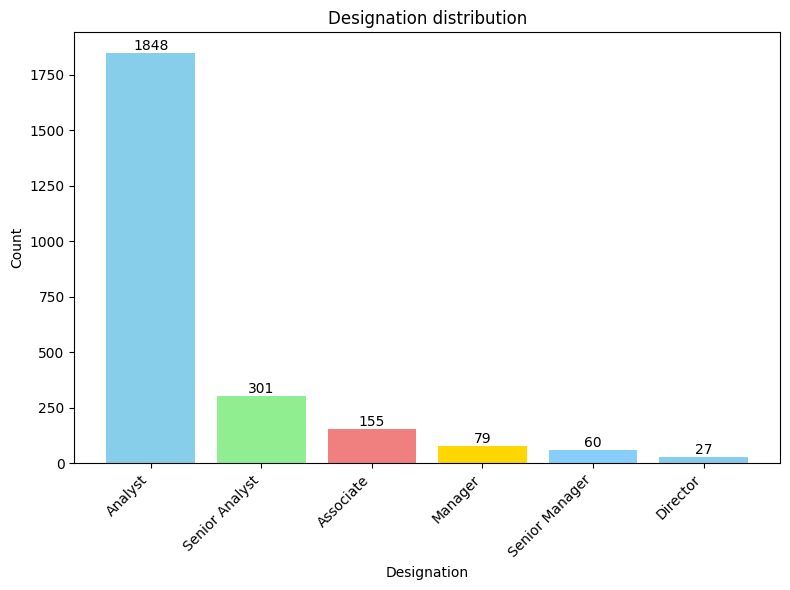

```python
# Count the quantity of each category
category_counts = df['DESIGNATION'].value_counts()

# Define colors for each category
colors = ['skyblue', 'lightgreen', 'lightcoral', 'gold', 'lightskyblue']  # Add more colors as needed

# Plotting the bar plot
plt.figure(figsize=(8, 6))
bars = plt.bar(category_counts.index, category_counts.values, color=colors[:len(category_counts)])

# Adding category names below the bars
plt.xticks(rotation=45, ha='right')
for bar in bars:
    plt.text(bar.get_x() + bar.get_width() / 2, bar.get_height(), bar.get_height(), ha='center', va='bottom')

plt.title('Designation distribution')
plt.xlabel('Designation')
plt.ylabel('Count')
plt.tight_layout()
plt.show()
```

Through assessing the frequency of each designation, we can discern the prevalence of various roles, from entry-level positions to senior management roles. This analysis enables us to understand the composition of the workforce and the distribution of responsibilities across different job levels.

the distribution of designations sheds light on the skillsets and expertise in demand within the data field. For instance, a higher prevalence of technical roles such as Analysts may indicate a growing emphasis on advanced analytics and data-driven solutions. Conversely, an increase in managerial or leadership designations may signal a shift towards organizational growth and strategic decision-making in data-driven initiatives.

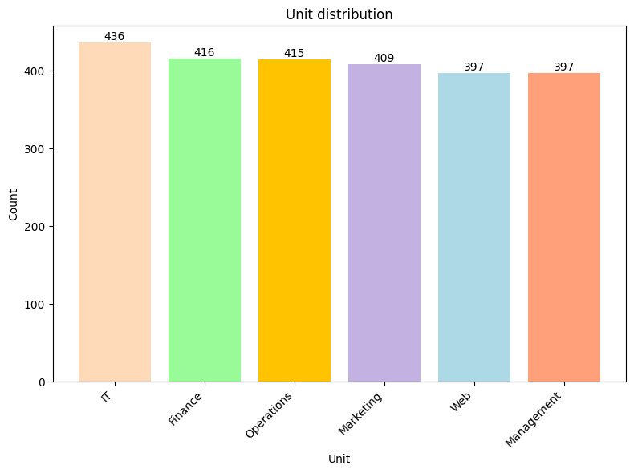

```python
category_counts = df['UNIT'].value_counts()
# Define pastel colors for each category
colors = ['#FFDAB9', '#98FB98','#FFC300', '#C3B1E1', '#ADD8E6', '#FFA07A']  # Pastel colors

# Plotting the bar plot
plt.figure(figsize=(8, 6))
bars = plt.bar(category_counts.index, category_counts.values, color=colors)

# Adding category names below the bars
plt.xticks(rotation=45, ha='right')
for bar in bars:
    plt.text(bar.get_x() + bar.get_width() / 2, bar.get_height(), bar.get_height(), ha='center', va='bottom')

plt.title('Unit distribution')
plt.xlabel('Unit')
plt.ylabel('Count')
plt.tight_layout()
plt.show()
```

By examining the height of each bar, we can discern the relative size of different departments, shedding light on the distribution of employment across various units. This analysis enables us to identify areas of high demand for specific skill sets and expertise within the data field market. Additionally, units with a larger number of employees may indicate sectors where salaries are relatively competitive, reflecting the demand for specialized skills and experience. Conversely, units with fewer employees may represent niche areas or emerging fields where talent is in high demand but may command higher salaries.

Moreover, tracking changes in the distribution of units over time can reveal evolving market trends and shifting employment opportunities within the data field

- In this step we will convert categorical variables that are relevant to training phase into numerical variables to ensure that the algorithms'mechanisms of working are out of pre processing flows :

```python
for col in ('SEX','DESIGNATION','UNIT'):
     label_encoder = LabelEncoder()
     df[col] = label_encoder.fit_transform(df[col]) # to convert the categorical columns to numerical columns
if 'SEX' in df.columns :
    df['SEX'] = LabelEncoder().fit_transform(df['SEX'])
print(df.head())
print(df.tail())
```

```
  FIRST NAME LAST NAME  SEX         DOJ CURRENT DATE  DESIGNATION   AGE  \
0     TOMASA     ARMEN    0   5-18-2014   01-07-2016            0  21.0
2      OLIVE      ANCY    0   7-28-2014   01-07-2016            0  21.0
3     CHERRY   AQUILAR    0  04-03-2013   01-07-2016            0  22.0
6     ELLIOT    AGULAR    1  09-02-2013   01-07-2016            0  22.0
8      KATHY     ALSOP    0   6-29-2014   01-07-2016            4  28.0

   SALARY  UNIT  LEAVES USED  LEAVES REMAINING  RATINGS  PAST EXP
0   44570     0         24.0               6.0      2.0         0
2   40955     0         23.0               7.0      3.0         0
3   45550     1         22.0               8.0      3.0         0
6   40339     3         19.0              11.0      5.0         0
8   63478     4         20.0              10.0      3.0         1
     FIRST NAME  LAST NAME  SEX        DOJ CURRENT DATE  DESIGNATION   AGE  \
2634  KATHERINE     ALSDON    0  6-28-2011   01-07-2016            5  36.0
2635     LOUISE    ALTARAS    0  1-14-2014   01-07-2016            0  23.0
2636      RENEE     ALVINO    0  1-23-2014   01-07-2016            0  21.0
2637       TERI  ANASTASIO    0  3-17-2014   01-07-2016            0  24.0
2638    GREGORY     ABARCA    1  9-18-2014   01-07-2016            0  24.0

      SALARY  UNIT  LEAVES USED  LEAVES REMAINING  RATINGS  PAST EXP
2634  185977     2         15.0              15.0      5.0        10
2635   45758     1         17.0              13.0      2.0         0
2636   47315     5         29.0               1.0      5.0         0
2637   45172     5         23.0               7.0      3.0         1
2638   49176     3         17.0              13.0      2.0         2
```

the following figures will be showcasing the distribution of each of the features that went through the process of label encoding :

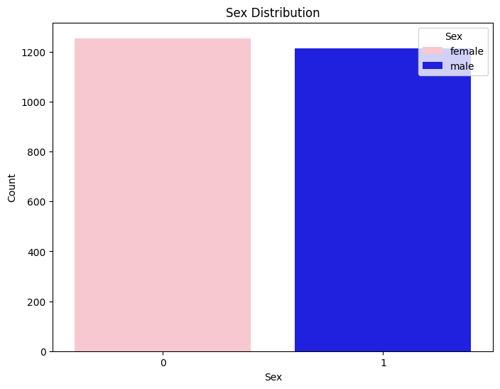

```python
# Convert 'SEX' column to numerical using LabelEncoder
label_encoder = LabelEncoder()
df['SEX'] = label_encoder.fit_transform(df['SEX'])

# Mapping numerical labels to original categories
sex_categories = {0: 'female', 1: 'male'}

# Plot the distribution with automatic labels
plt.figure(figsize=(8, 6))
sns.countplot(x='SEX', data=df, palette=['pink', 'blue'])
plt.title('Sex Distribution')
plt.xlabel('Sex')
plt.ylabel('Count')

# Create custom legend
legend_labels = [sex_categories[label] for label in sorted(df['SEX'].unique())]
plt.legend(legend_labels, title='Sex')

plt.show()
```

By examining the proportion of male and female employees, we can identify the presence of equal opportunities in this realm , fostering an inclusive environment in the data field which promotes for collaboration and innovation these insights suggests the presence of effective policies in the overall market emphasizing embracing a positive and creative environment for new professionals entering the data field .

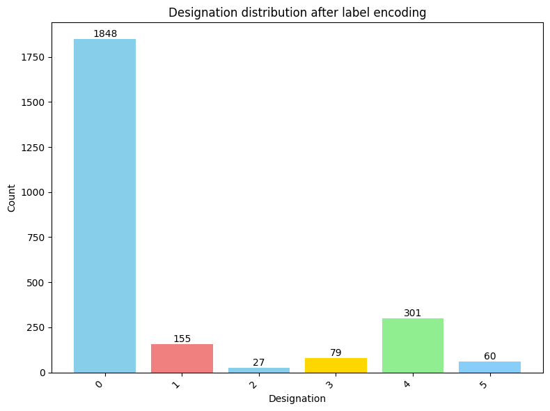

```python
# Count the quantity of each category
category_counts = df['DESIGNATION'].value_counts()

# Define colors for each category
colors = ['skyblue', 'lightgreen', 'lightcoral', 'gold', 'lightskyblue']  # Add more colors as needed

# Plotting the bar plot
plt.figure(figsize=(8, 6))
bars = plt.bar(category_counts.index, category_counts.values, color=colors[:len(category_counts)])

# Adding category names below the bars
plt.xticks(rotation=45, ha='right')
for bar in bars:
    plt.text(bar.get_x() + bar.get_width() / 2, bar.get_height(), bar.get_height(), ha='center', va='bottom')

plt.title('Designation distribution after label encoding')
plt.xlabel('Designation')
plt.ylabel('Count')
plt.tight_layout()
plt.show()
```

looking at the above figure and comparing it with the previous designation distribution figure we can see that :

- 0 : Analysts
- 1 : Associate
- 2 : Director
- 3 : Manager
- 4 : Senior Analyst
- 5 : Senior Manager

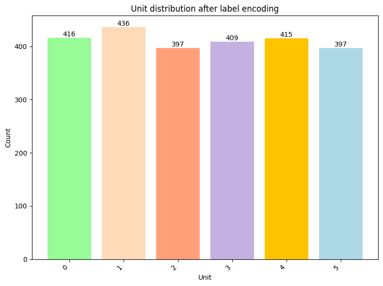

```python
category_counts = df['UNIT'].value_counts()
# Define pastel colors for each category
colors = ['#FFDAB9', '#98FB98','#FFC300', '#C3B1E1', '#ADD8E6', '#FFA07A']  # Pastel colors

# Plotting the bar plot
plt.figure(figsize=(8, 6))
bars = plt.bar(category_counts.index, category_counts.values, color=colors)

# Adding category names below the bars
plt.xticks(rotation=45, ha='right')
for bar in bars:
    plt.text(bar.get_x() + bar.get_width() / 2, bar.get_height(), bar.get_height(), ha='center', va='bottom')

plt.title('Unit distribution after label encoding')
plt.xlabel('Unit')
plt.ylabel('Count')
plt.tight_layout()
plt.show()
```

looking at the above figure and comparing it with the previous unit distribution figure we can see that :

- 0 : Finance
- 1 : IT
- 2 : Management
- 3 : Marketing
- 4 : Operations
- 5 : Web
- Past work experience / salary distribution :

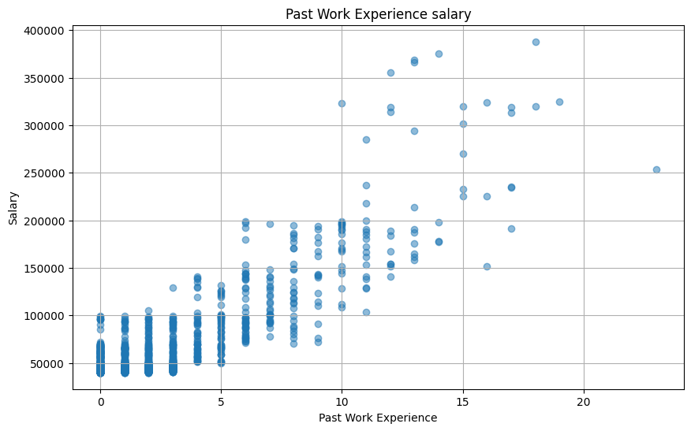

```python
plt.figure(figsize=(10, 6))
plt.scatter(df['PAST EXP'], df['SALARY'], alpha=0.5)
plt.title('Past Work Experience salary')
plt.xlabel('Past Work Experience')
plt.ylabel('Salary')
plt.grid(True)
plt.show()
```

- A positive slope indicates that as individuals accumulate more past work experience, their salaries tend to increase accordingly, reflecting a positive correlation between the two factors. Conversely, a negative slope would suggest a negative correlation, implying that higher levels of past work experience are associated with lower salaries.
- Dense clusters of points in specific areas indicate where the majority of individuals lie in terms of both past work experience and salary. For instance, a dense concentration of points in the lower-left corner of the plot suggests that many individuals have relatively low levels of past work experience and correspondingly low salaries.
- The spread of salaries across different levels of past work experience also warrants attention. A wide spread suggests significant variability in salaries, indicating that factors beyond past work experience may influence compensation, such as education, industry, or geographical location.

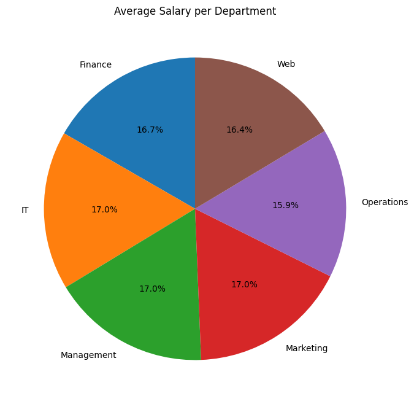

```python
department_names = {
    0: 'Finance',
    1: 'IT',
    2: 'Management',
    3: 'Marketing',
    4: 'Operations',
    5: 'Web'
}

# Replace department codes with names
df['UNIT'] = df['UNIT'].map(department_names)

# Group the data by department and calculate the average salary
average_salary_per_department = df.groupby('UNIT')['SALARY'].mean()

# Plotting the pie chart
plt.figure(figsize=(10, 8))
plt.pie(average_salary_per_department, labels=average_salary_per_department.index, autopct='%1.1f%%', startangle=90)
plt.title('Average Salary per Department')
plt.show()
```

- Large slices indicate higher average salaries within IT, Marketing and Management department with 17 % for each department of the salaries overall , along with 16.7 % for Finance department indicating lower average salaries from the overall salaries . Next is Web department with an average of 16.4 % of the overall salaries and finally with the lowest slice, the Operations department having an average of 15.9% of the overall salaries . This comparison helps identify departments where employees are compensated more generously relative to others. Departments with higher average salaries may attract and retain talent more effectively, while those with lower average salaries may face challenges in recruitment and retention.
- Comparing average salaries across departments can also provide insights into performance evaluation and reward mechanisms. Departments with higher average salaries may be more successful in achieving organizational goals, attracting top talent, or delivering high-value outputs. Conversely, departments with lower average salaries may require closer examination of performance metrics, employee engagement, and managerial effectiveness to address potential issues and improve overall performance.

```python
average_salary_all_data = df['SALARY'].mean()

print("Average Salary across all data points:", average_salary_all_data)
```

```
Average Salary across all data points: 58055.76477732794
```

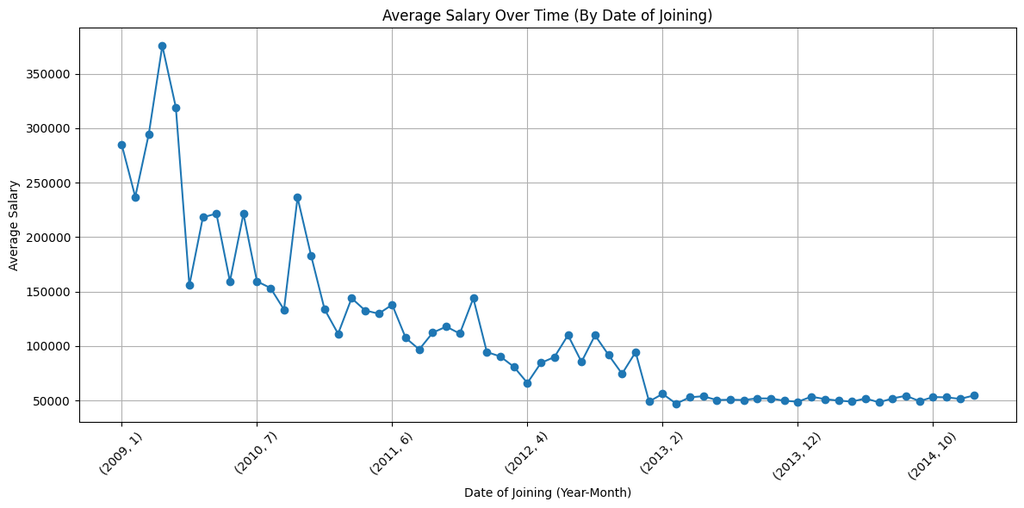

```python
# Convert 'DOJ' to datetime if it's not already in datetime format
df['DOJ'] = pd.to_datetime(df['DOJ'])

# Group the data by year and month of DOJ and calculate the average salary
average_salary_by_doj = df.groupby([df['DOJ'].dt.year, df['DOJ'].dt.month])['SALARY'].mean()

# Plot the time series
plt.figure(figsize=(12, 6))
average_salary_by_doj.plot(marker='o')
plt.title('Average Salary Over Time (By Date of Joining)')
plt.xlabel('Date of Joining (Year-Month)')
plt.ylabel('Average Salary')
plt.grid(True)
plt.xticks(rotation=45)
plt.tight_layout()
plt.show()
```

The terms "LEAVES USED" and "LEAVES REMAINING" typically refer to the number of vacation days, sick days, or other types of leave that an employee has utilized and the number of leave days they have remaining, respectively.

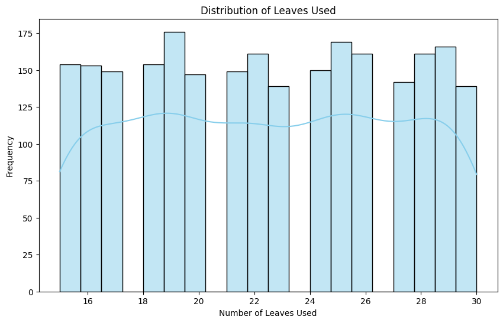

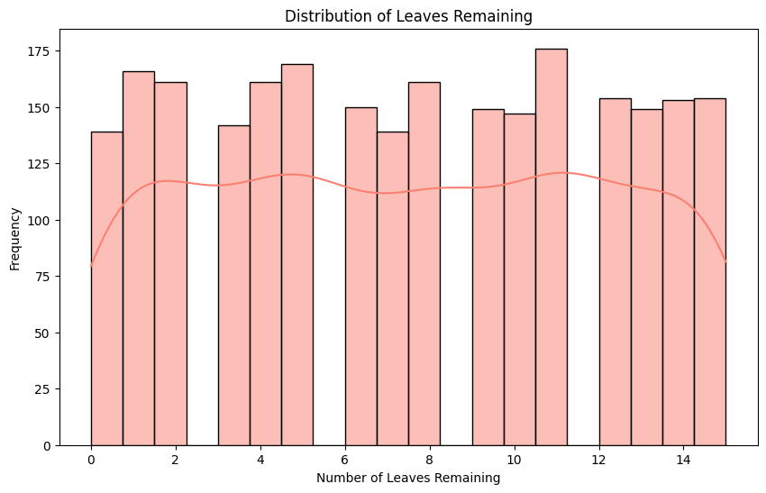

```python
# Distribution plot for number of leaves used
plt.figure(figsize=(10, 6))
sns.histplot(df['LEAVES USED'], kde=True, color='skyblue', bins=20)
plt.title('Distribution of Leaves Used')
plt.xlabel('Number of Leaves Used')
plt.ylabel('Frequency')
plt.show()

# Distribution plot for number of leaves remaining
plt.figure(figsize=(10, 6))
sns.histplot(df['LEAVES REMAINING'], kde=True, color='salmon', bins=20)
plt.title('Distribution of Leaves Remaining')
plt.xlabel('Number of Leaves Remaining')
plt.ylabel('Frequency')
plt.show()
```

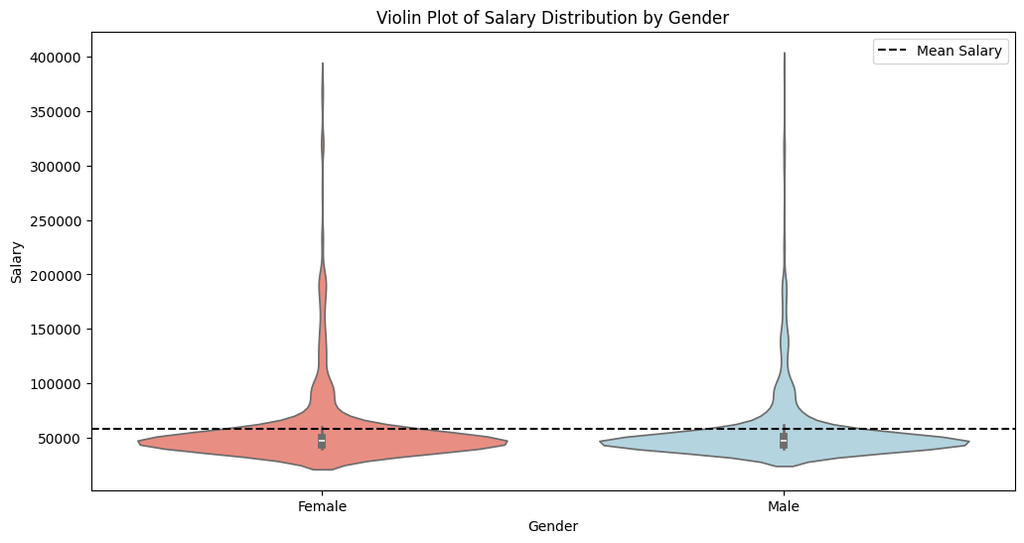

```python
# Map 0 to 'Female' and 1 to 'Male'
df['SEX'] = df['SEX'].map({0: 'Female', 1: 'Male'})

# Create the violin plot
plt.figure(figsize=(12, 6))
sns.violinplot(x='SEX', y='SALARY', data=df, palette={'Female': 'salmon', 'Male': 'lightblue'})
plt.axhline(df['SALARY'].mean(), color='black', linestyle='--', label='Mean Salary')
plt.title('Violin Plot of Salary Distribution by Gender')
plt.xlabel('Gender')
plt.ylabel('Salary')
plt.legend()
plt.show()
```

- The shaded areas represent the density of different salary levels for each category. We can slightly deduce a w ider distribution for Female salary distribution , which implies slightly less variability for male salary distribution. Observing this figure can also lead us to deduce that the male gender has slightly a higher mean salary compared to the female category.
- This visualization highlights potential disparities in salary distribution between the two gender groups.

Next we will be defining salary ranges based on the average salary we've determined previously as follows ( Average Salary : 58055.76477732794):

**Low salary :** Less than average salary

**Medium salary:** Between average salary and 1.5 times the average salary

**High salary :** More than 1.5 times the average salary

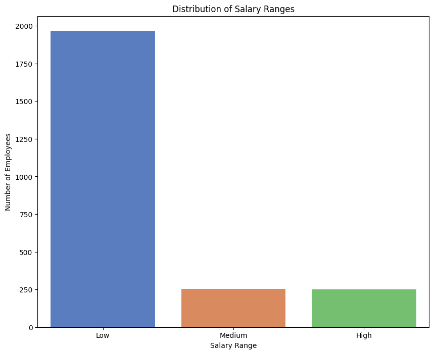

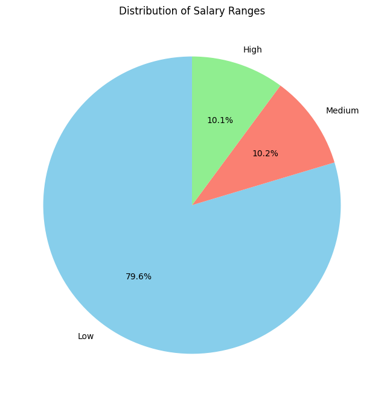

```python
df['Salary Range'] = pd.cut(df['SALARY'], bins=[-float('inf'), average_salary_all_data, 1.5 * average_salary_all_data, float('inf')],
                            labels=['Low', 'Medium', 'High'])

# Count the number of employees in each salary range
salary_range_counts = df['Salary Range'].value_counts()

# Plot the distribution of salary ranges
plt.figure(figsize=(10, 8))
sns.barplot(x=salary_range_counts.index, y=salary_range_counts.values, palette='muted')
plt.title('Distribution of Salary Ranges')
plt.xlabel('Salary Range')
plt.ylabel('Number of Employees')
plt.show()

# Optionally, plot a pie chart for the same data
plt.figure(figsize=(10, 8))
plt.pie(salary_range_counts, labels=salary_range_counts.index, autopct='%1.1f%%', startangle=90, colors=['skyblue', 'salmon', 'lightgreen'])
plt.title('Distribution of Salary Ranges')
plt.show()
```

Through using the following figures we're able to observe the distribution of the salary ranges that we defined earlier leading us to the following insights :

- The largest segment represents the Low salary range, accounting for approximately 79.6% of the distribution. Employees falling into this category receive salaries at the lower end of the spectrum. Dominance of this category promotes for a high competition among juniors entering this working field
- The Medium salary range constitutes around 10.2% of the distribution. Employees in this category earn moderate salaries, likely reflecting mid-level positions or roles with average compensation. It’s a smaller segment compared to the Low range, suggesting that fewer employees fall into this category. In otherwords transfering from medium range of salaries to high range of salaries is easier than transfering from low range of salaries to medium range of salaries
- The High salary range occupies approximately 10.1% of the chart. This segment represents employees with higher compensation—senior executives, specialized professionals, or those in critical roles. While smaller in proportion, it’s essential for retaining top talent and maintaining competitiveness.

=> the rate of difficulty of moving from a category of salary to another is decreasing as the competition is falling from category to another

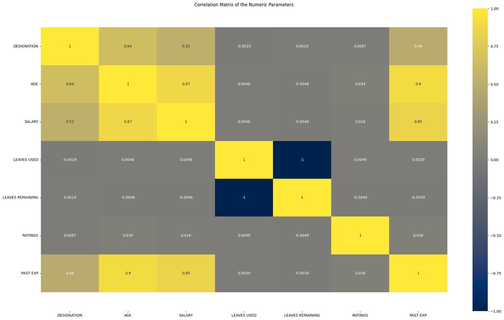

```python
# Select only numeric columns
numeric_df = df.select_dtypes(include=['number'])

# Create a heatmap of the correlation matrix
plt.figure(figsize=(25, 15))
ax = sns.heatmap(numeric_df.corr(), annot=True, cmap='cividis')
plt.title("Correlation Matrix of the Numeric Parameters")
bottom, top = ax.get_ylim()
ax.set_ylim(bottom + 0.5, top - 0.5)
plt.yticks(rotation=0)
plt.show()
```

- The variable “DESIGNATION” positively correlates with “SALARY” (0.52) . These positive correlations suggest that as one variable increases, the other tends to increase as well. This unveils that salary depends on the designation of employees in the data field .
- It is also clear that the age (which by turn is highly correlated with the past experience) and the past experience of employees in data field are highly correlated with the salary with relative 0.87 and 0.85 correlations promoting for the importance of past experience in this field.
- Designation is positively correlated with past experience this shows that positioning employees in their roles is related to their past experience wiht 0.48 correlation between the "DESIGNATION" and "PAST EXP" variables emphasizing the importance of past experience for better positions within this field and therefore better salaries .
- The correlation between age and designation arises out of the past experience that can be acquired from other fields or through non formal measures such as freelancing therefore not mentioned in the data provided that s why the "AGE" variables is highly correlated with " DESIGNATION" variables with 0.64 > 0.48 ( the past experience and the designation correlation)

## Train/Test model :

### Logistic Regression :

- Logistic regression is a powerful tool for binary classification tasks. Its simplicity and interpretability make it a popular choice for scenarios where understanding the relationship between features and the likelihood of a particular outcome is important. Logistic regression outputs probabilities of class membership, making it easy to interpret and analyze.
- Logistic regression is particularly useful when the relationship between predictors and the target variable is expected to be linear, and when the goal is to understand the probability of occurrence of a particular event.
- we will define a threshold that consists of the mean of salaries to identify the binary classification operation of our model
- We will initialize our logistic regression model and train it on the training data:

```python
# Separate the target variable that we want to predict
y = (numeric_df['SALARY'] > 58055.76477732794)  # Binary classification based on salary threshold
x = numeric_df.drop('SALARY', axis=1)

# Split the data into training and testing sets
x_train, x_test, y_train, y_test = train_test_split(x, y, test_size=0.2, random_state=42)

# Initialize the Logistic Regression model
log_reg = LogisticRegression()
log_reg.fit(x_train, y_train)

x_test.info()
x_test.head()
```

```
<class 'pandas.core.frame.DataFrame'>
Index: 494 entries, 1093 to 177
Data columns (total 6 columns):
 #   Column            Non-Null Count  Dtype
---  ------            --------------  -----
 0   DESIGNATION       494 non-null    int32
 1   AGE               494 non-null    float64
 2   LEAVES USED       494 non-null    float64
 3   LEAVES REMAINING  494 non-null    float64
 4   RATINGS           494 non-null    float64
 5   PAST EXP          494 non-null    int64
dtypes: float64(4), int32(1), int64(1)
memory usage: 25.1 KB
```

|  | DESIGNATION | AGE | LEAVES USED | LEAVES REMAINING | RATINGS | PAST EXP |
| --- | --- | --- | --- | --- | --- | --- |
| 1093 | 0 | 21.0 | 24.0 | 6.0 | 2.0 | 0 |
| 2316 | 3 | 33.0 | 28.0 | 2.0 | 2.0 | 6 |
| 1793 | 2 | 39.0 | 24.0 | 6.0 | 5.0 | 13 |
| 1618 | 0 | 23.0 | 29.0 | 1.0 | 4.0 | 1 |
| 363 | 0 | 23.0 | 29.0 | 1.0 | 4.0 | 0 |

```python
# Make predictions on the testing data
y_pred = log_reg.predict(x_test)
# Create a DataFrame to display the actual and predicted values
predictions_df = pd.DataFrame({'Actual': y_test, 'Predicted': y_pred})
print(predictions_df)
```

```
      Actual  Predicted
1093   False      False
2316    True       True
1793    True       True
1618   False      False
363    False      False
...      ...        ...
509    False      False
2267    True       True
1075   False      False
2047    True       True
177    False      False

[494 rows x 2 columns]
```

##### Evaluation of the model made using Logistic Regression:

- Accuracy: Accuracy represents the proportion of correctly classified instances out of all instances. Higher accuracy indicates better model performance.
- Confusion Matrix: A confusion matrix provides a summary of the predictions made by the model versus the actual labels. It consists of four numbers: true positives, true negatives, false positives, and false negatives.
- The ROC curve plots the trade-off between true positive rate (sensitivity) and false positive rate (1 - specificity) at different threshold values.The closer the curve is to the upper-left corner, the better the performance of the model.
- The AUC score quantifies the overall performance of the model. An AUC of 0.5 suggests random guessing, while an AUC of 1.0 indicates perfect classification.
- Specificity measures the proportion of actual negatives (true negatives, TN) that are correctly identified by the model.Specificity indicates how well the model avoids misclassifying negatives. =>TN / (TN + FP).
- Sensitivity measures the proportion of actual positives (true positives, TP) that are correctly identified by the model.Sensitivity indicates how well the model identifies positives. => TP / (TP + FN).

**Confusion Matrix:**

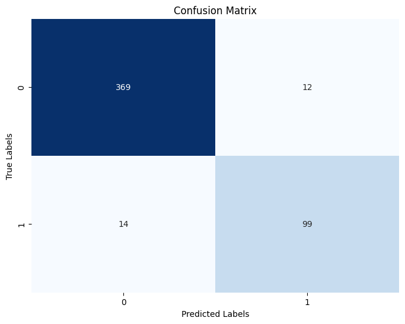

```python
# Create confusion matrix
conf_matrix = confusion_matrix(y_test, y_pred)
# Plot confusion matrix
plt.figure(figsize=(8, 6))
sns.heatmap(conf_matrix, annot=True, fmt='d', cmap='Blues', cbar=False)
plt.title('Confusion Matrix')
plt.xlabel('Predicted Labels')
plt.ylabel('True Labels')
plt.show()
```

- True Positive (TP): 99 instances were correctly classified as positive (salary exceeding the threshold).
- True Negative (TN): 369 instances were correctly classified as negative (salary below the threshold).
- False Positive (FP): 12 instances were incorrectly classified as positive (false alarms).
- False Negative (FN): 14 instances were incorrectly classified as negative (missed opportunities).

```python
# Calculate specificity
specificity = conf_matrix[0, 0] / (conf_matrix[0, 0] + conf_matrix[0, 1])

# Calculate sensitivity
sensitivity = conf_matrix[1, 1] / (conf_matrix[1, 0] + conf_matrix[1, 1])

print("Specificity (True Negative Rate):", specificity)
print("Sensitivity (True Positive Rate):", sensitivity)
```

```
Specificity (True Negative Rate): 0.968503937007874
Sensitivity (True Positive Rate): 0.8761061946902655
```

- The **specificity** of approximately **0.97** indicates that the model correctly identifies about 97% of individuals with salaries below the threshold (true negatives). This means that the model has a high ability to avoid misclassifying individuals with salaries below the threshold as positive cases.
- The **sensitivity** of approximately **0.88** suggests that the model correctly identifies around 88% of individuals with salaries exceeding the threshold (true positives). This indicates that the model has a moderate-to-high ability to correctly identify individuals with salaries above the threshold.

=> the logistic regression model performs well in distinguishing between individuals with salaries above and below the threshold, with a particularly high specificity, However there's a room for improvement in terms of sensitivity as there are still a proportion that is worth mentioning being missed by the model

**Accuracy score :**

```python
# Calculate accuracy
accuracy = accuracy_score(y_test, y_pred)
print("Accuracy:", accuracy)
```

```
Accuracy: 0.9473684210526315
```

- An accuracy of 0.947 indicates that the logistic regression model correctly predicted the class labels for approximately 94.7% of the instances in the test set. In other words, the model's predictions are accurate for almost 95% of the data points. This suggests that the model performs well in classifying instances into the defined classes (salary above or below the mean of salary in the data) based on the given features
- Accuracy alone is often insufficient for evaluating a binary classification model, especially in cases of class imbalance. High accuracy can be misleading if one class dominates; a model predicting only the majority class could still achieve high accuracy. That's why alongside accuracy, sensitivity ensures the model captures true positives, and specificity ensures it correctly identifies true negatives, providing a comprehensive evaluation of the model's performance.

**ROC curve & AUC score :**

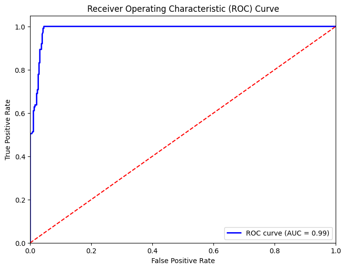

```
AUC Score: 0.9874573200473834
```

```python
# Calculate the predicted probabilities
y_pred_proba = log_reg.predict_proba(x_test)[:,1]

# Calculate the false positive rate, true positive rate, and thresholds
fpr, tpr, thresholds = roc_curve(y_test, y_pred_proba)

# Calculate the area under the ROC curve (AUC)
auc = roc_auc_score(y_test, y_pred_proba)

# Plot the ROC curve
plt.figure(figsize=(8, 6))
plt.plot(fpr, tpr, color='blue', lw=2, label='ROC curve (AUC = %0.2f)' % auc)
plt.plot([0, 1], [0, 1], color='red', linestyle='--')
plt.xlim([0.0, 1.0])
plt.ylim([0.0, 1.05])
plt.xlabel('False Positive Rate')
plt.ylabel('True Positive Rate')
plt.title('Receiver Operating Characteristic (ROC) Curve')
plt.legend(loc='lower right')
plt.show()

print("AUC Score:", auc)
```

- The ROC curve hugs the top left corner, indicating high TPR and low FPR. The labeled AUC of 0.99 suggests nearly perfect model performance, this means that the model correctly identifies a large proportion of actual positive cases, also we can deduce that the model minimizes the number of false alarms (predicting positive when the actual class is negative).
- The AUC score of 0.99 reflects excellent discrimination ability of the logistic regression model in classifying instances into the defined classes (e.g., salary above or below the mean). n.b : The AUC summarizes the overall performance of the model across different threshold settings.

**Hyper-tuning of the model:**

GridSearch is a widely used hyperparameter tuning technique that systematically explores a predefined grid of hyperparameters to find the optimal combination for a machine learning model. By evaluating every possible set of hyperparameters through cross-validation, GridSearch identifies the best parameters that improve the model's performance based on a specified metric, such as accuracy or RMSE. This method ensures a thorough search and can significantly enhance the model's predictive capabilities, albeit at the cost of increased computational time and resources.

```python
# Define the parameter grid
param_grid = {
    'penalty': ['l1', 'l2'],
    'C': [1, 10, 100, 1000, 10000],
    'solver': ['liblinear']
}
# Initialize the Logistic Regression model
log_reg = LogisticRegression()

# Initialize GridSearchCV
grid_search = GridSearchCV(estimator=log_reg, param_grid=param_grid, cv=5, n_jobs=-1)

# Fit GridSearchCV to the training data
grid_search.fit(x_train, y_train)

# Get the best parameters and the best score
best_params = grid_search.best_params_
best_score = grid_search.best_score_

print("Best Parameters:", best_params)
print("Best Score:", best_score)
```

```
Best Parameters: {'C': 1, 'penalty': 'l1', 'solver': 'liblinear'}
Best Score: 0.9458534714230918
```

### Linear Regression :

Linear regression offers several advantages that make it well-suited for salary prediction in the data field. Firstly, linear regression models are inherently interpretable, providing straightforward insights into how each predictor variable contributes to variations in the target variable, such as salary. Additionally, linear regression is robust to outliers and can handle noisy data effectively, which is common in real-world datasets. This robustness simplifies the data preprocessing step and saves time during model development. Moreover, linear regression can capture both linear and non-linear relationships between predictor variables and salary, providing flexibility in modeling complex scenarios where the relationship between variables is not strictly linear.

```python
linear_reg = LinearRegression()

# Fit the model to the training data
linear_reg.fit(x_train, y_train)

# Predict the target variable
y_pred_linear = linear_reg.predict(x_test)

x_test.info()
x_test.head()
```

```
<class 'pandas.core.frame.DataFrame'>
Index: 494 entries, 1093 to 177
Data columns (total 6 columns):
 #   Column            Non-Null Count  Dtype
---  ------            --------------  -----
 0   DESIGNATION       494 non-null    int32
 1   AGE               494 non-null    float64
 2   LEAVES USED       494 non-null    float64
 3   LEAVES REMAINING  494 non-null    float64
 4   RATINGS           494 non-null    float64
 5   PAST EXP          494 non-null    int64
dtypes: float64(4), int32(1), int64(1)
memory usage: 25.1 KB
```

|  | DESIGNATION | AGE | LEAVES USED | LEAVES REMAINING | RATINGS | PAST EXP |
| --- | --- | --- | --- | --- | --- | --- |
| 1093 | 0 | 21.0 | 24.0 | 6.0 | 2.0 | 0 |
| 2316 | 3 | 33.0 | 28.0 | 2.0 | 2.0 | 6 |
| 1793 | 2 | 39.0 | 24.0 | 6.0 | 5.0 | 13 |
| 1618 | 0 | 23.0 | 29.0 | 1.0 | 4.0 | 1 |
| 363 | 0 | 23.0 | 29.0 | 1.0 | 4.0 | 0 |

```python
predictions_df = pd.DataFrame({'Actual': y_test, 'Predicted': y_pred_linear})
print(predictions_df)
```

```
      Actual  Predicted
1093   False  -0.093262
2316    True   0.904785
1793    True   1.039062
1618   False   0.027832
363    False   0.061523
...      ...        ...
509    False   0.124512
2267    True   0.641113
1075   False   0.110840
2047    True   0.616211
177    False   0.179199

[494 rows x 2 columns]
```

##### Evaluation of the model made using Linear Regression :

- Mean Absolute Error (MAE): This metric represents the average absolute difference between the predicted and actual values.
  - Easy to interpret.
  - Treats all errors equally, which means it is not sensitive to outliers
- Mean Squared Error (MSE): MSE represents the average of the squared differences between the predicted and actual values.
  - Highlights larger errors, which can be useful in some contexts.
  - Commonly used in optimization problems as it is differentiable.
- Root Mean Squared Error (RMSE): RMSE is the square root of the MSE and provides an interpretable scale as it's in the same units as the target variable.
  - Penalizes larger errors more than MAE, similar to MSE.
  - Easier to interpret in the context of the original data.
- R-squared (R2): R-squared represents the proportion of the variance in the dependent variable (target) that is predictable from the independent variables (features).A value closer to 1 indicates a better fit of the model to the data.
  - Provides a normalized measure of how well the model explains the target variable, making it easier to compare across different models and datasets.
  - Values range from 0 to 1, where higher values indicate better fit.

```python
# Calculate Mean Absolute Error (MAE)
mae = mean_absolute_error(y_test, y_pred_linear)

# Calculate Mean Squared Error (MSE)
mse = mean_squared_error(y_test, y_pred_linear)

# Calculate Root Mean Squared Error (RMSE)
rmse = np.sqrt(mse)

# Calculate R-squared (R²) Score
r2 = r2_score(y_test, y_pred_linear)

print("Mean Absolute Error (MAE):", mae)
print("Mean Squared Error (MSE):", mse)
print("Root Mean Squared Error (RMSE):", rmse)
print("R-squared (R²) Score:", r2)
```

```
Mean Absolute Error (MAE): 0.1572749952555668
Mean Squared Error (MSE): 0.05044656195621259
Root Mean Squared Error (RMSE): 0.22460312098502236
R-squared (R²) Score: 0.7140552994321814
```

- MAE : Approximately 0.1573. This means that, on average, the model's predictions are off by about 0.1573 units.
- MSE : Approximately 0.0504. Since MSE squares the errors, it penalizes larger errors more heavily than MAE.
- RMSE : Approximately 0.2246. It's particularly useful as it directly interprets the average magnitude of the errors. In other words, the average prediction error is about 0.2246 units.
- R² Score: R-squared value of 0.7141 indicates that the model explains approximately 71.41% of the variance in the target variable, which is a moderate level of explanation.

**Hyper-Tuning Of linear regression model:**

```python
# Define the parameter grid for Ridge regression
param_grid = {
    'alpha': [0.001, 0.01, 0.1, 1, 10, 100]  # Regularization strength
}

# Initialize the Ridge regression model
ridge_reg = Ridge()

# Initialize GridSearchCV
grid_search = GridSearchCV(estimator=ridge_reg, param_grid=param_grid, scoring='r2', cv=5, n_jobs=-1)

# Fit GridSearchCV to the training data
grid_search.fit(x_train, y_train)

# Get the best parameters and the best score
best_params = grid_search.best_params_
best_score = grid_search.best_score_

print("Best Parameters:", best_params)
print("Best R-squared Score:", best_score)
```

```
Best Parameters: {'alpha': 100}
Best R-squared Score: 0.6673353593695579
```

The R-squared value of 0.714 for the linear regression model indicates that approximately 71.4% of the variability in the target variable is explained by the independent variables included in the model. This suggests a moderate fit of the linear regression model to the training data, capturing some of the underlying relationships.

### Decision Tree Regressor:

A decision tree regressor offers several advantages. Firstly, decision trees are intuitive and easy to interpret, making them suitable for explaining the factors that contribute to variations in target variables, such as salary. This interpretability is crucial for businesses to understand the underlying patterns driving key outcomes. Additionally, decision trees are robust to outliers and do not require extensive data preprocessing, saving time and effort in the model development process. Furthermore, decision trees can capture non-linear relationships between predictors and the target variable, allowing for more accurate predictions in complex scenarios where the relationship between variables is not simply linear.

- Simplicity, interpretability, and flexibility make the decision tree regressor a suitable tool for predicting continuous outcomes.
- We will be initializing our Decision Tree Regressor and training the model on the training data :

```python
# Separate the target variable that we want to predict
y = numeric_df['SALARY']
x = numeric_df.drop('SALARY', axis=1)

# Split the data into training and testing sets
x_train, x_test, y_train, y_test = train_test_split(x, y, test_size=0.2, random_state=42)

# Initialize the Decision Tree Regressor
tree_reg = DecisionTreeRegressor(max_depth=4, random_state=42)
tree_reg.fit(x_train, y_train)

x_test.info()
x_test.head()
```

```
<class 'pandas.core.frame.DataFrame'>
Index: 494 entries, 1093 to 177
Data columns (total 6 columns):
 #   Column            Non-Null Count  Dtype
---  ------            --------------  -----
 0   DESIGNATION       494 non-null    int32
 1   AGE               494 non-null    float64
 2   LEAVES USED       494 non-null    float64
 3   LEAVES REMAINING  494 non-null    float64
 4   RATINGS           494 non-null    float64
 5   PAST EXP          494 non-null    int64
dtypes: float64(4), int32(1), int64(1)
memory usage: 25.1 KB
```

|  | DESIGNATION | AGE | LEAVES USED | LEAVES REMAINING | RATINGS | PAST EXP |
| --- | --- | --- | --- | --- | --- | --- |
| 1093 | 0 | 21.0 | 24.0 | 6.0 | 2.0 | 0 |
| 2316 | 3 | 33.0 | 28.0 | 2.0 | 2.0 | 6 |
| 1793 | 2 | 39.0 | 24.0 | 6.0 | 5.0 | 13 |
| 1618 | 0 | 23.0 | 29.0 | 1.0 | 4.0 | 1 |
| 363 | 0 | 23.0 | 29.0 | 1.0 | 4.0 | 0 |

```python
# predictions on the testing data
y_pred = tree_reg.predict(x_test)

# Create a DataFrame to display the actual and predicted values
predictions_df = pd.DataFrame({'Actual': y_test, 'Predicted': y_pred})
print(predictions_df)
```

```
      Actual      Predicted
1093   48203   45089.316858
2316  128247  120870.555556
1793  213987  368887.000000
1618   46343   45089.316858
363    45123   45089.316858
...      ...            ...
509    48996   44783.282051
2267   88069   87866.600000
1075   44428   44783.282051
2047   66747   59835.560000
177    40251   45089.316858

[494 rows x 2 columns]
```

##### Evaluation of the model made using decision tree regrerssor:

When evaluating a Decision Tree Regressor, or any regression model, it is essential to use various metrics to comprehensively understand the model's performance. Here's why we use Mean Absolute Error (MAE), Mean Squared Error (MSE), Root Mean Squared Error (RMSE), and R-squared (R²)

```python
mae = mean_absolute_error(y_test, y_pred)
mse = mean_squared_error(y_test, y_pred)
rmse = np.sqrt(mse)
r2 = r2_score(y_test, y_pred)

print("Mean Absolute Error:", mae)
print("Mean Squared Error:", mse)
print("Root Mean Squared Error:", rmse)
print("R-squared:", r2)
```

```
Mean Absolute Error: 4556.649802328279
Mean Squared Error: 134707502.37866947
Root Mean Squared Error: 11606.356119759099
R-squared: 0.8962606293219735
```

- MAE : The MAE is approximately 4556.65. This means that, on average, the model's predictions are off by about $4556.65.
- MSE : The MSE is approximately 134,707,502.38. Since MSE squares the errors, it penalizes larger errors more heavily than MAE.
- RMSE: The RMSE is approximately 11,606.36. It's particularly useful as it directly interprets the average magnitude of the errors. In otherwords, the average prediction error is about $11,606.36.
- R-squared : The R-squared value of 0.896 indicates that the model explains approximately **89.6%** of the variance in the salary, which is quite good. This suggests that the model fits the data well and captures most of the variability in the target variable.

=> Our regression model performs reasonably well in predicting salaries, with a relatively low error and a high proportion of variance explained by the features.

**Decision tree Regressor VS Linear Regression :**

**Hyper-Tuning of Decision Tree Regressor model:**

```python
# Define the parameter grid
param_grid = {
    'max_depth': [3, 6],
    'min_samples_split': [2, 5, 10],
    'min_samples_leaf': [1, 2, 4]
}

# Initialize the Decision Tree Regressor model
tree_reg = DecisionTreeRegressor(random_state=42)

# Initialize GridSearchCV
grid_search = GridSearchCV(estimator=tree_reg, param_grid=param_grid, scoring='r2', cv=5, n_jobs=-1)

# Fit GridSearchCV to the training data
grid_search.fit(x_train, y_train)

# Get the best parameters and the best score
best_params = grid_search.best_params_
best_score = grid_search.best_score_

print("Best Parameters:", best_params)
print("Best R-squared Score:", best_score)
```

```
Best Parameters: {'max_depth': 6, 'min_samples_leaf': 1, 'min_samples_split': 10}
Best R-squared Score: 0.9383217033462673
```

The best R-squared score of 0.938 obtained from the grid search represents the highest R-squared value achieved among all combinations of hyperparameters tested during the tuning process. This indicates that the model with the selected hyperparameters provides an even better fit to the data, explaining approximately 93.8% of the variability in the target variable.

both R-squared values indicate strong performance of the regression model in capturing the relationships between the independent and dependent variables. The improvement from 0.896 to 0.938 demonstrates the effectiveness of hyperparameter tuning in enhancing the model's explanatory power.

We can notice that even after Hyper-Tuning both models Linear Regression is not capable even to surpass Decision Tree's R squared score before Hyper Tuning, Highlighting the limitations of linear regression in capturing the complex relationships present in the dataset.

### Random Forest Regressor :

The Random Forest Regressor is a powerful ensemble learning technique that utilizes multiple decision trees to make predictions. Random Forest can handle large and complex datasets effectively, making it suitable for analyzing salary data from various sources. By aggregating the predictions of multiple decision trees, Random Forest reduces overfitting and provides more robust predictions compared to individual decision trees. This is particularly beneficial in salary prediction, where the goal is to accurately estimate the salaries based on various employee attributes and historical data.

```python
y = numeric_df['SALARY']
x = numeric_df.drop('SALARY', axis=1)

# Split the data into training and testing sets
x_train, x_test, y_train, y_test = train_test_split(x, y, test_size=0.2, random_state=42)

# Initialize the Random Forest Regressor
rf_reg = RandomForestRegressor(n_estimators=100, random_state=42)

# Train the model on the training data
rf_reg.fit(x_train, y_train)
```

```
RandomForestRegressor(random_state=42)
```

```python
# predictions on the testing data
y_pred = rf_reg.predict(x_test)

# Create a DataFrame to display the actual and predicted values
predictions_df = pd.DataFrame({'Actual': y_test, 'Predicted': y_pred})
print(predictions_df)
```

```
      Actual      Predicted
1093   48203   44383.518740
2316  128247  119824.900000
1793  213987  306537.250000
1618   46343   47452.106286
363    45123   43418.182132
...      ...            ...
509    48996   43649.167000
2267   88069   91565.205000
1075   44428   46581.595833
2047   66747   60443.641250
177    40251   44518.582310

[494 rows x 2 columns]
```

##### Evaluation of the model made using Random Forest regrerssor:

As mentioned before, this regression model requires the use of Mean Absolute Error (MAE), Mean Squared Error (MSE), Root Mean Squared Error (RMSE), and R-squared (R²) for evaluation.

```python
# Calculate evaluation metrics
mae = mean_absolute_error(y_test, y_pred)
mse = mean_squared_error(y_test, y_pred)
rmse = np.sqrt(mse)
r2 = r2_score(y_test, y_pred)

# Print the evaluation metrics
print(f'Mean Absolute Error (MAE): {mae}')
print(f'Mean Squared Error (MSE): {mse}')
print(f'Root Mean Squared Error (RMSE): {rmse}')
print(f'R-squared (R²): {r2}')
```

```
Mean Absolute Error (MAE): 4398.484425653068
Mean Squared Error (MSE): 82970225.46072125
Root Mean Squared Error (RMSE): 9108.799342433736
R-squared (R²): 0.936103937625436
```

- Mean Absolute Error (MAE): 4398.48 On average, the model's predictions are off by about $4398.48. This shows the average error magnitude without considering its direction.
- Mean Squared Error (MSE): 82,970,225.46 Since MSE squares the errors, it penalizes larger errors more heavily. This value indicates that there are some substantial errors, as squaring exaggerates the effect of larger discrepancies.
- Root Mean Squared Error (RMSE): 9108.80 The RMSE, which is in the same units as the target variable (salary), shows that the average prediction error is about $9108.80. This metric is useful for understanding the error size in the context of the original data.
- R-squared (R²): 0.9361 An R² value of 0.9361 indicates that the model explains approximately 93.61% of the variance in the salary data. This suggests a very good fit, meaning the model is highly effective at capturing the relationships between the predictors and the target variable.

**Random Forest Regressor VS Linear Regression :**

**Random Forest Regressor VS decision tree Regressor :**

The Mean Absolute Error (MAE) for the Random Forest Regressor is 4398.48, which is lower than the Decision Tree Regressor's MAE of 4556.65. This indicates that, on average, the Random Forest model's predictions are more accurate and closer to the actual values. Additionally, the Mean Squared Error (MSE) for the Random Forest Regressor is 82,970,225.46, significantly lower than the Decision Tree Regressor's MSE of 134,707,502.38. This suggests that the Random Forest model is better at minimizing larger errors, as MSE penalizes these more heavily. Furthermore, the Root Mean Squared Error (RMSE) for the Random Forest Regressor is 9108.80, compared to 11,606.36 for the Decision Tree Regressor. The lower RMSE for the Random Forest model indicates a smaller average magnitude of prediction errors, making its predictions more reliable. Finally, the R-squared (R²) value for the Random Forest Regressor is 0.9361, whereas the Decision Tree Regressor has an R² of 0.896. This higher R² value signifies that the Random Forest model explains approximately 93.61% of the variance in the salary data, compared to 89.6% for the Decision Tree model.

**Hyper-Tuning of Random Forest Regressor model:**

```python
# Define the parameter grid
param_grid = {
    'n_estimators': [50, 100],
    'max_depth': [3, 6],
    'min_samples_split': [2, 5, 10],
    'min_samples_leaf': [1, 2, 4]
}

# Initialize the Decision Tree Regressor model
rf_reg = RandomForestRegressor(random_state=42)

# Initialize GridSearchCV
grid_search = GridSearchCV(estimator=rf_reg, param_grid=param_grid, scoring='r2', cv=5, n_jobs=-1)

# Fit GridSearchCV to the training data
grid_search.fit(x_train, y_train)

# Get the best parameters and the best score
best_params = grid_search.best_params_
best_score = grid_search.best_score_

print("Best Parameters:", best_params)
print("Best R-squared Score:", best_score)
```

```
Best Parameters: {'max_depth': 6, 'min_samples_leaf': 1, 'min_samples_split': 5, 'n_estimators': 50}
Best R-squared Score: 0.9470991693929223
```

The best R-squared score of 0.947 obtained from the grid search represents the highest R-squared value achieved among all combinations of hyperparameters tested during the tuning process. This indicates that the model with the selected hyperparameters provides an even better fit to the data, explaining approximately 94.7% of the variability in the target variable.

both R-squared values suggest that the Random Forest model performs well in explaining the variance in the target variable, with the hyperparameter tuning process further improving its performance.

we can notice that the performance of the decision tree model better closed the gap of performance in terms of explaining variability between it and the random forest regressor model after hyper tuning both models ,Although random forest is always providing better results

### Extreme Gradient Boosting :

Extreme Gradient Boosting (XGBoost) is a versatile machine learning algorithm renowned for its prowess in handling structured/tabular data for regression tasks. Derived from the concept of gradient boosting, XGBoost enhances predictive accuracy by iteratively improving weak learners, thereby reducing bias and variance. Its regularization techniques mitigate overfitting risks, ensuring robust generalization to unseen data. XGBoost excels in regression scenarios, such as predicting continuous variables like house prices, stock prices, or salary amounts, where its ability to capture complex relationships within data shines. With features like built-in cross-validation and support for custom loss functions, XGBoost offers flexibility and consistently delivers high-performance models for regression challenges.

```python
import xgboost as xgb
xgb_reg = xgb.XGBRegressor(max_depth=4, random_state=42)
# Fit the model
xgb_reg.fit(x_train, y_train)
# Predict the target variable
y_pred = xgb_reg.predict(x_test)
```

```python
predictions_df = pd.DataFrame({'Actual': y_test, 'Predicted': y_pred})
print(predictions_df)
```

```
      Actual      Predicted
1093   48203   44610.097656
2316  128247  122031.460938
1793  213987  318620.968750
1618   46343   45369.929688
363    45123   45404.015625
...      ...            ...
509    48996   44435.746094
2267   88069   96589.179688
1075   44428   45504.375000
2047   66747   63549.531250
177    40251   45365.539062

[494 rows x 2 columns]
```

##### Evaluation of the model made using Extreme Gradient Boosting:

As mentioned before, this regression model requires the use of Mean Absolute Error (MAE), Mean Squared Error (MSE), Root Mean Squared Error (RMSE), and R-squared (R²) for evaluation.

```python
# Calculate Mean Absolute Error (MAE)
mae = mean_absolute_error(y_test, y_pred)
print("Mean Absolute Error:", mae)

# Calculate Mean Squared Error (MSE)
mse = mean_squared_error(y_test, y_pred)
print("Mean Squared Error:", mse)

# Calculate Root Mean Squared Error (RMSE)
rmse = np.sqrt(mse)
print("Root Mean Squared Error:", rmse)

# Calculate R-squared (R²)
r2 = r2_score(y_test, y_pred)
print("R-squared (R²) Score:", r2)
```

```
Mean Absolute Error: 4718.605808767713
Mean Squared Error: 111010420.18094845
Root Mean Squared Error: 10536.148261150678
R-squared (R²) Score: 0.9145099498920081
```

- The MAE is approximately $4718.61. This means that, on average, the XGBoost Regressor's predictions are off by about $4718.61 from the actual salary values.
- The MSE is approximately $111,010,420.18. The MSE measures the average of the squared errors between the predicted and actual values. It's a large value, indicating that there are significant differences between the predicted and actual salaries.
- The RMSE is approximately $10,536.15. The RMSE provides the average magnitude of the errors and is particularly useful for interpreting the error scale. Here, it indicates that, on average, the predictions are off by around $10,536.15 from the actual salary values.
- The R-squared value is approximately 0.9145. This indicates that the XGBoost Regressor explains approximately 91.45% of the variance in the salary data. A higher R-squared value suggests that the model fits the data well and captures most of the variability in the target variable.

=> These evaluation metrics suggest that the XGBoost Regressor performs well in predicting salaries, with relatively low errors and a high degree of explained variance.

**XGBoost VS Linear Regression:**

**XGBoost VS decision tree Regressor :**

While the XGBoost Regressor exhibits a slightly higher Mean Absolute Error (MAE) of approximately 4718.61 compared to the Decision Tree Regressor's MAE of 4556.65, indicating marginally less accurate predictions, it showcases lower Mean Squared Error (MSE) and Root Mean Squared Error (RMSE) values, standing at approximately 111,010,420.18 and 10,536.15 respectively, in contrast to the Decision Tree Regressor's respective values of 134,707,502.38 and 11,606.36. These suggest that the XGBoost Regressor may better minimize larger errors and provide predictions with a smaller average magnitude of error. Moreover, the XGBoost Regressor boasts a slightly higher R-squared (R²) score of approximately 0.9145 compared to the Decision Tree Regressor's 0.896, indicating its potential to capture slightly more variability in the target variable.

Both models perform reasonably well, the XGBoost Regressor demonstrates a promising edge in terms of error minimization and capturing variability in the salary data with minor differences

**XGBoost VS Random Forest Regressor :**

The Mean Absolute Error (MAE) for the XGBoost Regressor is 4718.61, slightly higher than the Random Forest Regressor's MAE of 4398.48. This suggests that, on average, the Random Forest model's predictions are slightly more accurate and closer to the actual values compared to the XGBoost Regressor. Additionally, the Mean Squared Error (MSE) for the XGBoost Regressor is 111,010,420.18, higher than the Random Forest Regressor's MSE of 82,970,225.46. The lower MSE for the Random Forest model indicates that it is better at minimizing larger errors. Furthermore, the Root Mean Squared Error (RMSE) for the XGBoost Regressor is 10,536.15, compared to 9108.80 for the Random Forest Regressor. The lower RMSE for the Random Forest model indicates a smaller average magnitude of prediction errors, making its predictions potentially more reliable. Finally, the R-squared (R²) value for the XGBoost Regressor is 0.9145, slightly lower than the Random Forest Regressor's R² of 0.9361. This higher R² value for the Random Forest model suggests that it explains a larger proportion of the variance in the salary data compared to the XGBoost Regressor. Overall, both models perform well, but the Random Forest Regressor demonstrates slightly better performance in terms of accuracy and variance explanation.

**Hyper-tuning XGBoost:**

```python
# Define the parameter grid
param_grid = {
    'n_estimators': [50, 100],
    'max_depth': [3, 6],
    'learning_rate': [0.1, 0.01]
}


# Create XGBoost classifier
xgb_reg = xgb.XGBRegressor( random_state=42)
# Create GridSearchCV instance
grid_search = GridSearchCV(estimator=xgb_reg, param_grid=param_grid, scoring='r2', cv=5, verbose=1)

# Fit the GridSearchCV object to the data
grid_search.fit(x_train, y_train)

# Get the best parameters and best AUC score
best_params = grid_search.best_params_
best_score = grid_search.best_score_

print("Best parameters:", best_params)
print("Best R² score:", best_score)
```

```
Fitting 5 folds for each of 8 candidates, totalling 40 fits
Best parameters: {'learning_rate': 0.1, 'max_depth': 3, 'n_estimators': 100}
Best R² score: 0.9510928935494973
```

The R-squared value of 0.914 for the XGBoost model indicates that approximately 91.4% of the variability in the target variable is explained by the independent variables included in the model. This suggests a strong fit of the XGBoost model to the training data, capturing the underlying relationships effectively.

The best R-squared score of 0.951 obtained from the grid search represents the highest R-squared value achieved among all combinations of hyperparameters tested during the tuning process. This indicates that the model with the selected hyperparameters provides an even better fit to the data, explaining approximately 95.1% of the variability in the target variable.

both R-squared values suggest that the XGBoost model performs well in explaining the variance in the target variable, with the hyperparameter tuning process further improving its performance.

After Hyper-tuning both models we can deduce that the XGBoost model was able to overcome the high R-squared of the Random Forest to have the best r-squared between the models we've fitted until now explaining 95.1% of the variablity in the target variable